# Applied Data Science (Prof. Dr. Kauffeldt)

## 3 Regressionsmodelle

Überblick:

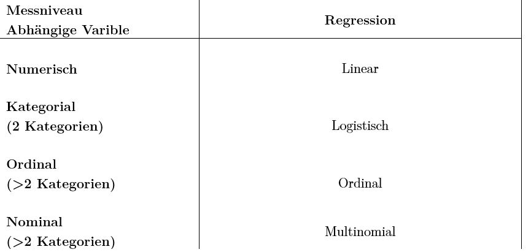

### 3.1 Lineare Regression

#### 3.1.1 Grundlegende Idee

In den Sozialwissenschaften möchten wir oft untersuchen, ob eine unabhängige Variable (X) eine abhängige Variable (Y) beeinflusst. Zum Beispiel: Erhöhen Marketingausgaben (X) den Umsatz (Y)?

Die Idee der **linearen Regression** besteht darin, eine Gerade an die Daten anzupassen. Die theoretische Gleichung eines solchen Modells lautet:

$$Sales = \beta_0 + \beta_1 \cdot Marketing + \varepsilon,$$

wobei

- $\beta_0, \beta_1$ = Achsenabschnitt, Steigung
- $\varepsilon$ = Fehlerterm, der Variablen berücksichtigt, die nicht in der Gleichung enthalten sind (z. B. Reputation des Unternehmens, Produktqualität)

Wie findet man die optimale Gerade?

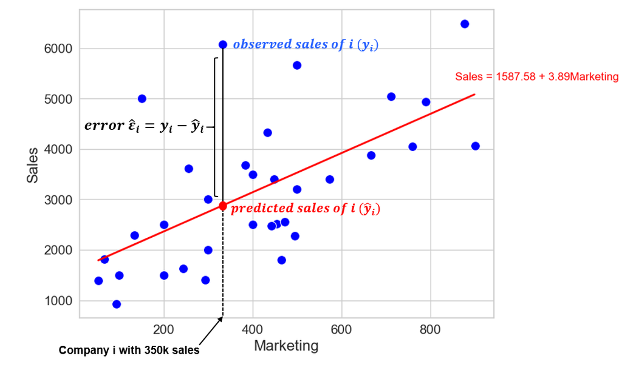

Jede Gerade führt zu spezifischen Fehlern. Wir möchten diejenige Gerade finden, die die Fehler minimiert – also die Linie, die den Datenpunkten am nächsten liegt.  
Wie aggregieren wir die Fehler?

- Die totale Summe der Fehler ($\varepsilon_1+\dots+\varepsilon_n$) hat den Nachteil, dass sich negative und positive Abweichungen teilweise gegenseitig aufheben.

Die Lösung besteht darin, die gesamte Summe der *quadrierten* Fehler (SSR = Sum of Squared Residuals) zu minimieren (*Ordinary Least Squares (OLS)*-Ansatz):

$$SSR=\varepsilon_1^2+\dots+\varepsilon_n^2$$

Im Fall einer einfachen linearen Regression (eine abhängige Variable Y, eine unabhängige Variable X) können die geschätzten Regressionskoeffizienten wie folgt berechnet werden: $$\hat{\beta}_1=\frac{cov(X,Y)}{var(X)} \:\: und\:\:\hat{\beta}_0=\frac{\Sigma y_i-\hat{\beta}_1\Sigma x_i}{n} .$$ Im obigen Beispiel:

- Kovarianz(Marketing, Umsatz) = 207797,65
- Varianz(Marketing) = 53472,15
- Summe Umsatz = 104432,81
- Summe Marketing = 13392
- n = 33

Daher (Unterschiede zur geschätzten Geraden oben ergeben sich durch Rundungsdifferenzen):

$$\hat{\beta}_1=\frac{207797.65}{53472.15}\approx 3.89\:\:und\:\:\hat{\beta}_0=\frac{104432.81-3.89\cdot 13392}{33}\approx 1585.99 .$$

Interpretation der Koeffizienten:

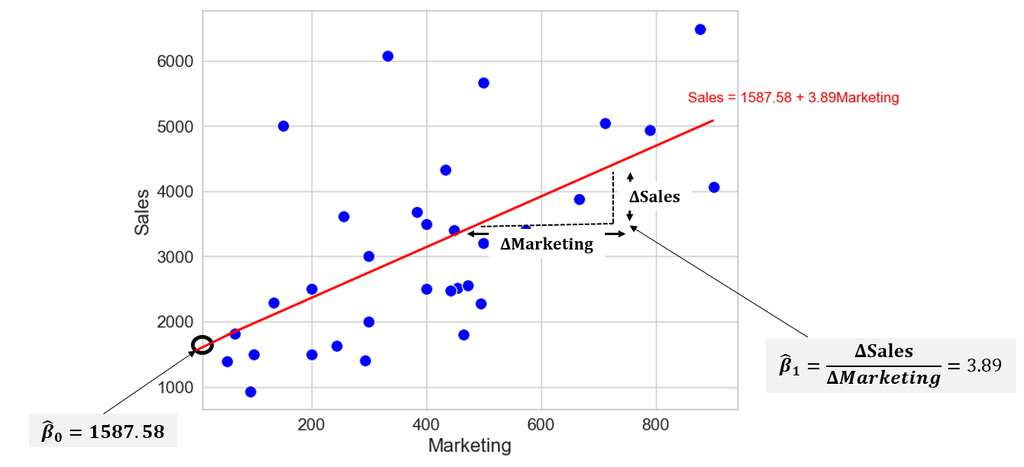

- Achsenabschnitt ($\hat{\beta}_0$): Der geschätzte Umsatz eines Unternehmens mit 0 Marketingausgaben beträgt 1'587'580 \$
- Steigung ($\hat{\beta}_1$): Eine Einheitserhöhung der Marketingausgaben erhöht den Umsatz um ca. 3,89 \$

#### 3.1.2 Multiple Lineare Regression

Wir möchten möglicherweise weitere unabhängige Variablen zu unserem Modell hinzufügen. Die theoretische Regressionsgleichung mit k unabhängigen Variablen lautet wie folgt:

$$Y = \beta_0+\beta_1\cdot X_1+\dots+\beta_k\cdot X_k+\varepsilon$$

Konzeptionell unterscheiden wir zwischen Zielvariablen und Kontrollvariablen. Angenommen, $X_1$ und $X_2$ sind die Zielvariablen. Wir untersuchen ihren Einfluss auf $Y$, während wir für $X_3, \dots, X_k$ kontrollieren.

Die Mathematik funktioniert ähnlich wie beim einfachen Modell, aber nun müssen wir uns eine Regressionsebene (oder einen Hyperebene) vorstellen.

Beispiel:

$$ Sales = \beta_0 + \beta_1 \cdot Marketing + \beta_2 \cdot Quality + \varepsilon, $$

wobei *Quality* durch die durchschnittliche Produktlebensdauer gemessen wird.

#### 3.1.3 Dummy-/One-Hot-Codierung bei kategorialen unabhängigen Variablen

Kategoriale Variablen (nominal oder ordinal) nehmen Kategorien als Werte an. Eine Regressionsgleichung kann jedoch nur mit Zahlen arbeiten.  
Da nominale Varialen keine Ordnung besitzen, müssen wir diese in Indikatorvariablen umwandeln. Ordinale Variablen kann man entweder entsprechend deren Ordnung kodieren oder ebenfalls Indikatorvariablen verwenden. Bei der Kodierung wird implizit angenommen, dass die Abstände von aufeinanderfolgenden Kategorien gleich sind. Dies kann problematisch sein. Im Falle von Indikatorvariablen verliert man die Ordnung bei ordinalen Variablen.

Beispiel: Variable „Location“, die die Kategorien *Asia, Europe, USA* annehmen kann.

Indikatorvariablen:

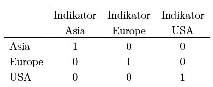

Wir können jedoch nicht alle 3 Indikatorvariablen verwenden, da zwei immer die dritte perfekt vorhersagen. Diese Abhängigkeit würde dazu führen, dass das Regressionsmodell kollabiert. Daher müssen wir eine der Kategorien weglassen (welche ist egal). Die ausgelassene Kategorie dient als Referenzkategorie: Alle Effekte werden im Verhältnis zu dieser Kategorie gemessen. Im Allgemeinen hat man bei K Kategorien K-1 Indikatorvariablen.

#### 3.1.4 Beispiel Lineare Regression

Schritte Regressionsanalyse

1. Schreibe vermutete Ursache-Wirkungs-Beziehungen mit Kontrollvariablen auf.
2. Überprüfen der Voraussetzungen.
3. Schreiben Sie die geschätzte Regressionsgleichung auf und interpretieren Sie das Ergebnis.
4. Ggf. weitere Robustheitsprüfungen.

**Schritt 1:** Theoretische Regressionsgleichung

Wir möchten untersuchen, wie sich Marketingausgaben auf den Umsatz auswirken, während wir für den Standort und die Reputation eines Unternehmens kontrollieren. Reputation ist eine ordinale Variable und nimmt die Werte *High, Medium, Low* an. Wir entscheiden uns diese zu kodieren (2, 1, 0), statt Indikatorvariablen zu verwenden.

**Schritt 2:** Voraussetzungen überprüfen

Voraussetzungen Linearen Regression

- **LR1. Numerische abhängige Variable.**
- **LR2. Linearität.** Es besteht eine lineare Beziehung zwischen der abhängigen und den unabhängigen Variablen.
- **LR3. Fehlen perfekter (Multi)kollinearität.** Es besteht keine perfekte lineare Beziehung zwischen unabhängigen Variablen.
- **LR4. Strikte Exogenität.** Die bedingten Mittelwerte der Fehler sind null ($E[\varepsilon_i\:|\:x_i]=0$).
- **LR5. Homoskedastizität.** Die Fehler haben für alle i,j gleiche bedingte Varianzen $(var(\varepsilon_i\:|\:x_i)=var(\varepsilon_j\:|\:x_j))$.
- **LR6. Keine Autokorrelation.** Die Fehler sind für alle i,j nicht korreliert ($cov(\varepsilon_i,\varepsilon_j)=0$).
- **LR7. Normalität.** Die Fehler folgen einer multivariaten Normalverteilung.

LR1 bis LR3 beziehen sich auf die Variablen, die restlichen Voraussetzungen auf die Fehlerterme.

LR1.  
Umsatz ist numerisch. ✔

LR2.  
`Analysen -> Regression -> Lineare Regression -> Modellanpassung -> F-Test`

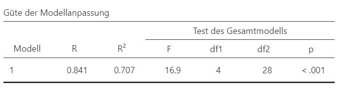

LR3.  
`Analysen -> Regression -> Lineare Regression -> Überprüfung der Voraussetzungen -> Kollinearitätsstatistik`

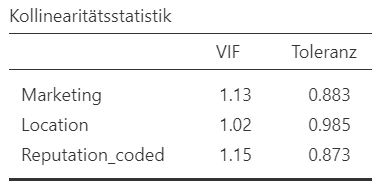

Erfüllt ✔

LR4.  
Das direkte Überprüfen der strikten Exogenität kann herausfordernd sein, da es sich nicht um etwas handelt, das man direkt mit einem statistischen Test testen kann.  
Oft ist der beste Ansatz, die theoretische Grundlage für strikte Exogenität zu berücksichtigen. Zum Beispiel, wenn Sie es mit Zeitreihendaten zu tun haben, überlegen Sie, ob vergangene Werte der abhängigen Variablen oder der Prädiktoren den Fehlerterm beeinflussen könnten. Ebenso, wenn Sie mit Querschnittsdaten arbeiten, überlegen Sie, ob der Fehlerterm durch unbeobachtete Faktoren, die mit den Prädiktoren zusammenhängen, beeinflusst werden könnte.  
Ein nützlicher erster Schritt ist es jedoch, die Residuen (Fehler) des Regressionsmodells gegen die Prädiktorvariablen zu plotten.

- Wenn in diesen Plots ein systematisches Muster zu erkennen ist (z. B. eine gekrümmte Beziehung), könnte dies darauf hindeuten, dass die Annahme der strikten Exogenität verletzt ist, da es eine Abhängigkeit zwischen den Residuen und den Prädiktoren impliziert.
- Idealerweise sollten die Residuen beim Plotten gegen eine unabhängige Variable eine zufällige Streuung um Null zeigen (kein Muster).

`Analysen -> Regression -> Lineare Regression -> Überprüfung der Voraussetzungen -> Diagramme der Residuen`

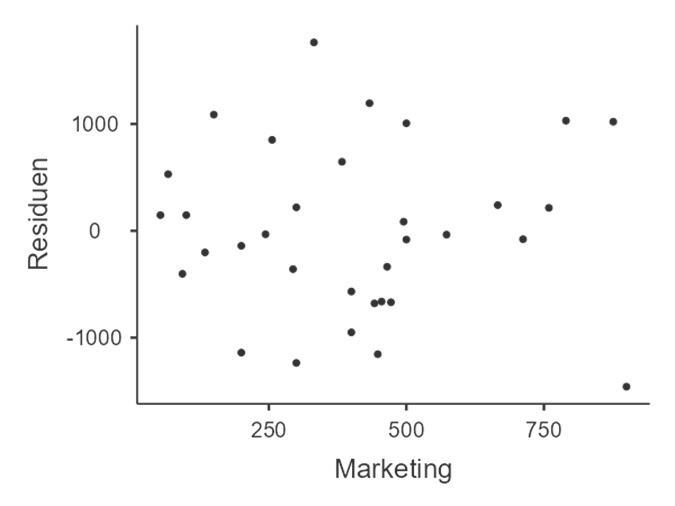

LR 5.  
Visuell: Eine der einfachsten und häufigsten Methoden zur Überprüfung der Homoskedastizität besteht darin, die Residuen gegen die angepassten Werte (vorhergesagten Werte) aus Ihrem Regressionsmodell zu plotten.

- So geht's: Berechnen Sie zuerst die Residuen: Residuen = Beobachtet − Vorhergesagt. Dann plotten Sie die Residuen auf der y-Achse und die angepassten Werte auf der x-Achse.
- Worauf Sie achten sollten: Wenn der Plot eine zufällige Streuung zeigt (kein klares Muster), weist dies auf Homoskedastizität hin. Wenn der Plot ein klares Muster zeigt, wie zum Beispiel eine Trichterform (die Residuen nehmen mit den angepassten Werten zu oder ab), weist dies auf Heteroskedastizität hin.

`Analysen -> Regression -> Lineare Regression -> Überprüfung der Voraussetzungen -> Diagramme der Residuen`

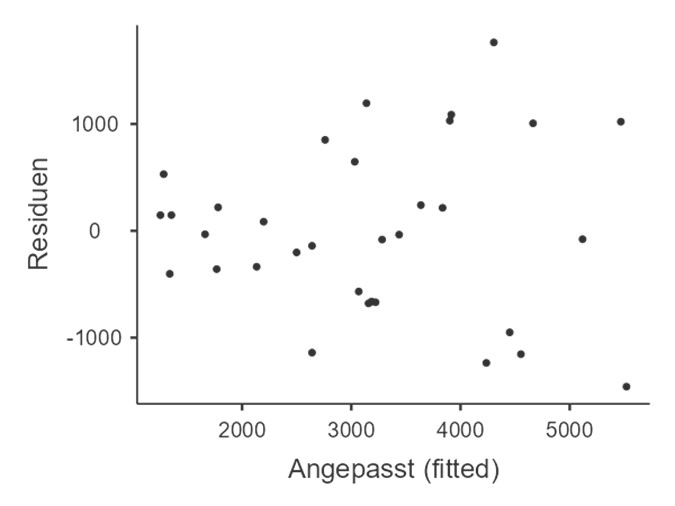

LR6.  
`Analysen -> Regression -> Lineare Regression -> Überprüfung der Voraussetzungen -> Autokorrelationstest`

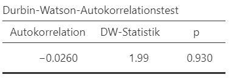

Durbin-Watson Autokorrleationstest: $$H_0: Keine Autokorrelation$$ $$H_1: Autokorrelation$$ Erfüllt ✔

LR7.  
`Analysen -> Regression -> Lineare Regression -> Überprüfung der Voraussetzungen -> Test auf Normalverteilung`

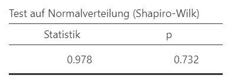

Shapiro-Wilk Test: $$H_0: Normalverteilung$$ $$H_1: Keine Normalverteilung$$ Erfüllt ✔

**Schritt 3:** Schreiben Sie die geschätzte Regressionsgleichung auf und interpretieren Sie das Ergebnis.

`Analysen -> Regression -> Lineare Regression`

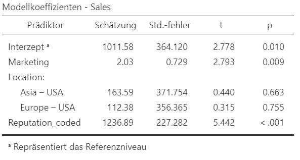

Geschätzte Regressionsgleichung (Koeffizienten gerundet auf ganze Zahlen):

$$Sales=1012+2\cdot Marketing+164\cdot Location_{Asia}+112\cdot Location_{Europe}+1237\cdot Reputation$$

Interpretation → Vorlesung.

#### 3.1.5 Potentielle Probleme

Überblick:

1. Überanpassung des Modells an die Daten (Overfitting)
2. Moderationseffekt
3. Mediationseffekt
4. Omitted Variable Bias

Überanpassung des Modells an die Daten (Overfitting)

Das Hinzufügen zusätzlicher unabhängiger Variablen zum Modell erhöht stets $ R^2 $. Allerdings ist nicht klar, ob dies auf einen tatsächlichen kausalen Effekt oder lediglich auf einen mechanischen Zusammenhang zurückzuführen ist: Wenn wir unabhängige Variablen hinzufügen, verlieren wir Freiheitsgrade. Dies kann zu einem künstlichen Anstieg von $R^2 $ führen.

Ein solcher künstlicher Anstieg des $ R^2 $ wird als *Overfitting* bezeichnet. Das bedeutet, dass das Modell zu stark an die vorhandenen Daten angepasst wurde.

Eine Möglichkeit, Overfitting zu erkennen, ist das adjustierte $R^2_{\text{adj}}$. Im Gegensatz zu $R^2$ berücksichtigt es die Freiheitsgrade und kann sinken, wenn zusätzliche unabhängige Variablen hinzugefügt werden: $$R^2_{adj}=\bigg(𝑹^𝟐−\frac{𝒌}{𝒏−𝟏}\bigg)\cdot\bigg(\frac{𝒏−𝟏}{𝒏−𝒌−𝟏}\bigg)$$

`Analysen -> Regression -> Lineare Regression -> Modellanpassung -> Adjustiertes R2`

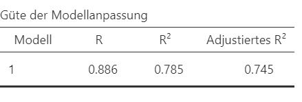

Moderationseffekt

Moderator = Dritte Variable, die die Stärke des Effekts bestimmt.

Beispiel: Qualität könnte einen schwächeren Effekt auf den Umsatz haben, wenn das Unternehmen eine geringere Reputation hat.

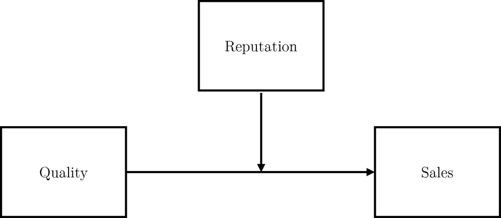

Die Steigungen der Reputation „mittel“ und „hoch“ scheinen ziemlich ähnlich zu sein. Die Steigung von „niedrig“ ist jedoch flacher:

`Analysen -> Regression -> Exploration -> Streudiagramm`

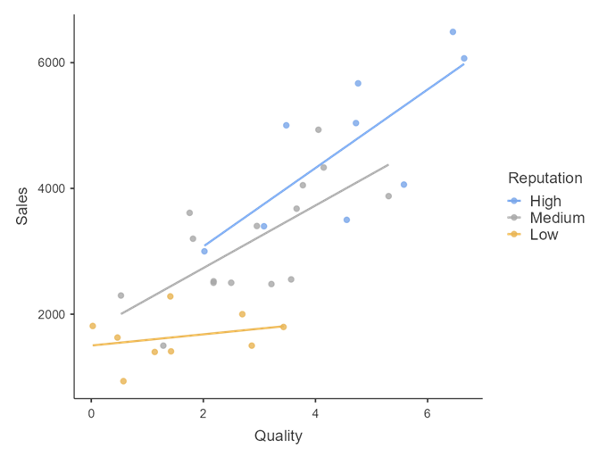

Um zu testen, ob tatsächlich eine Moderation vorliegt, müssen wir die Interaktionen $quality \times reputation$ in das Modell aufnehmen. Wenn diese Interaktionen signifikant ist, haben wir einen Hinweis auf einen Moderationseffekt gefunden:

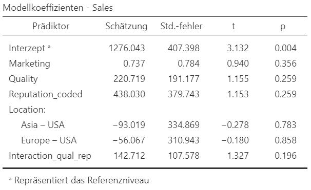

Der p-Wert des Interaktionsterms ist größer als 5 %. Daher haben wir keinen Hinweis auf einen Moderationseffekt gefunden.

Mediationseffekt

Mediator = dritte Variable, durch die der Effekt entsteht

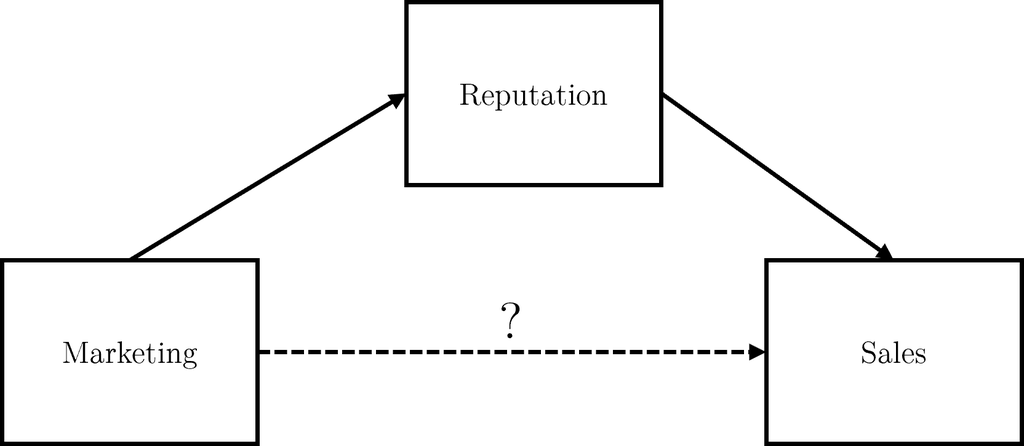

Möglichkeiten, um zu testen, ob ein Mediationseffekt vorliegt:

1. *Jamovi medmod Modul*  
   Lade medmod Modul herunter, dann `medmod -> Mediation`

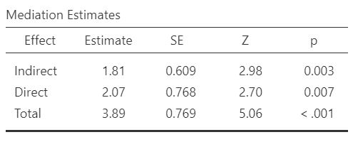

   (Es wurde ein Bootstrapverfahren verwendet, da die Stichprobe zu klein war für ein Testverfahren über den üblichen Weg)
2. *Händisch*
   1. Schätze Gesamteffekt durch die Regression ohne Mediator: $Sales=a_0+a\cdot Marketing+e_1$ (Koeffizient a = Gesamteffekt)

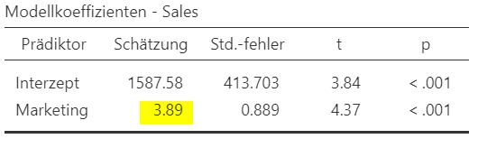

   2. Schätze direkten Effekt durch die Regression mit Mediator: $Sales=b_0+a'\cdot Marketing+b\cdot Reputation+e_2$ (Koeffizient a' = direkter Effekt)

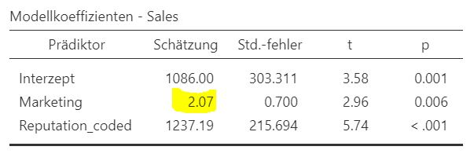

   3. Indirekter Effekt. Zunächst Abschätzung des Effekts der Variable auf den Mediator: $Reputation= c_0+c\cdot Marketing+e_3$. Der indirekte Effekt ist dann: $b\cdot c$.

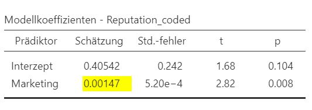

   4. Bestimmung der Signifikanz des indirekten Effekts mit dem Sobel-Test, dessen Teststatistik standardnormalverteilt ist:

$$Z=\frac{b\times c}{\sqrt{c^2\cdot se_b^2+b^2\cdot se_c^2}},$$

wobei se die Standardfehler der Koeffizientenschätzer sind. Mit den Zahlen von oben:

$$Z=\frac{1237,19\times 0,00147}{\sqrt{0,00147^2\cdot 215,694^2+1237,19^2\cdot 0.00052^2}}=\frac{1.8186693}{0.7172}=2,54$$

Nun können wir mit Hilfe des R-Editors in Jamovi den p-Wert berechnen. Der R-Befehl lautet:

$$p-Wert=pnorm(2.54, lower.tail = FALSE)=0.005611$$

Interpretation der Resultate:

Wenn der indirekte Effekt signifikant ist, liegt eine der folgenden Mediationen vor:

- Volle Mediation: Direkter Effekt ist nicht mehr signifikant.
- Partielle Mediation: Direkter Effekt bleibt signifikant, ist aber kleiner.

Omitted Variable Bias  
Die Ergebnisse einer Regression sind verzerrt, wenn eine relevante unabhängige Variable weggelassen wird. Eine Variable ist relevant, wenn die folgenden Bedingungen erfüllt sind:

1. Die Variable muss einen Einfluss auf die abhängige Variable haben.
2. Die Variable muss mit einer anderen unabhängigen Variable korreliert sein.

Unser Datensatz enthält eine weitere Variable, die relevant sein könnte: die Produktqualität, gemessen an der durchschnittlichen Lebensdauer der Produkte.  
Was wäre der Fall, wenn Qualität relevant wäre? Aus Vereinfachungsgründen lassen wir Reputation und Location weg.

- Wahre kausale Beziehung: \( Sales = \beta_0 + \beta_1 \cdot Marketing + \beta_2 \cdot Quality \)
- Unser Modell: \( Sales = \gamma_0 + \gamma_1 \cdot Marketing \)

Wenn Qualität und Marketingausgaben korreliert sind, gilt:

$$ Quality = \alpha_0 + \alpha_1 \cdot Marketing $$

Setzen wir diese Gleichung in die wahre kausale Beziehung ein, ergibt sich:

$$\gamma_1=\beta_1+\beta_2\alpha_1$$

Daher haben wir anstelle des wahren Effekts von Marketing auf den Umsatz $\beta_1$ den Wert $\gamma_1$ geschätzt, der je nach Richtung der Korrelation zwischen Marketing und Qualität größer oder kleiner als $\beta_1$ sein kann.

### 3.2 Logistische Regression

#### 3.2.1 Grundlegende Idee

Bei einer kategorialen abhängigen Variablen wird nicht der Variablenwert selbst, sondern die Wahrscheinlichkeit, dass eine bestimmte Kategorie angenommen wird, geschätzt. Ein linearer Ansatz kann hier zu Problemen führen: Vorhergesagte Wahrscheinlichkeiten könnten außerhalb des Einheitsintervalls liegen, die Fehlerterme sind nicht normalverteilt und ein konstanter marginaler Effekt würde angenommen werden.

Die logistische Regression schätzt die Wahrscheinlichkeit bei einer binären Variablen (nimmt die Kategorien 0 und 1 an) wie folgt: $$P(Y=1)=\frac{e^z}{e^z+1},$$ wobei $z=\beta_0+\beta_1 X_1 +\dots+\beta_k X_k$.
Alternativ: $$log\bigg(\frac{P(Y=1)}{1-P(Y=1)}\bigg)=z=\beta_0+\beta_1 X_1 +\dots+\beta_k X_k,$$ wobei der Term $\bigg(\frac{P(Y=1)}{1-P(Y=1)}\bigg)$ die *Odds* genannt wird.

#### 3.2.2 Beispiel

**Schritt 1:** Theoretische Regressionsgleichung

Können wir das Geschlecht vorhersagen basierend auf der Körpergröße?

$$P(Y=Mann)=\frac{e^z}{e^z+1},$$

$z=\beta_0+\beta_1 Größe$

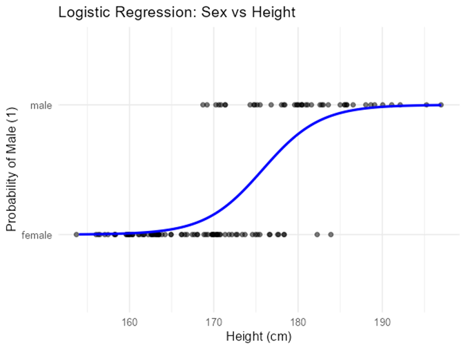

Erzeugung der Regressionslinie der logistischen Regression entweder durch das *linear models* Modul oder anhand des folgenden R-Codes:

'Load necessary package' `library(ggplot2)`

'Fit logistic regression model' `model <- glm(sex ~ height, data = data, family = binomial)`

'Generate a sequence of height values for the logistic curve' `height_seq <- seq(min(data$height), max(data$height), length.out = 300)`

'Predict probabilities using type = "response"'

[output not shown]

'(Optional) Check the range of predicted probabilities' `print(range(predicted_probs)) # Should be within 0 and 1`

'Create a dataframe for the logistic curve' `curve_data <- data.frame(height = height_seq, probability = predicted_probs)`

'Plot scatterplot with jitter and logistic regression curve'

```
ggplot(data, aes(x = height, y = sex)) +
geom_jitter(width = 0.5, height = 0.00, alpha = 0.5, color = "black") +  # Binary outcome jittered
geom_line(data = curve_data, aes(x = height, y = probability+1), color = "blue", size = 1) +  # Logistic curve
labs(title = "Logistic Regression: Sex vs Height", x = "Height (cm)", y = "Probability of Male (1)") +
theme_minimal()
```

**Schritt 2:** Voraussetzungen überprüfen

Voraussetzungen Logistische Regression

- **LOG1. Binäre abhängige Variable.**
- **LOG2. Linearität.** Es besteht eine lineare Beziehung zwischen den log-odds der abhängigen Variablen und den unabhängigen Variablen.
- **LOG3. Fehlen perfekter (Multi)kollinearität.** Es besteht keine perfekte lineare Beziehung zwischen unabhängigen Variablen.
- **LOG4. Hinreichende Stichprobengröße.** Daumenregel: 10 bis 20 Beobachtungen pro unabhängiger Variable.
- **LOG5. Unabhängigkeit.** Beobachtungen sollten unabhängig voneinander sein (keine wiederholten Messungen an denselben Versuchspersonen).

Besprechung der Voraussetzungen → Vorlesung.

**Schritt 3:** Schreiben Sie die geschätzte Regressionsgleichung auf und interpretieren Sie das Ergebnis.

Model fit: Log-Likelihood-Ratio-Test ($H_0: \beta_1=0$, $H_1:\beta_1\neq 0$)

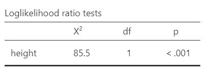

Geschätzte Regressionsgleichung:

$$P(Y=Mann)=\frac{e^z}{e^z+1},$$

$z=-51,521+0,293 Größe$

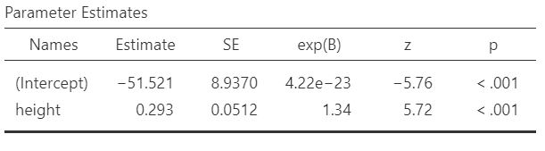

Exp(B) = 1,34 ist die Odds-Ratio und bedeutet, dass mit jeder 1 cm Zunahme der Körpergröße die Chancen männlich zu sein um 34 % steigen.

### 3.3 Ordinale Regression

#### 3.3.1 Grundlegende Idee

Der grundlegende Gedanke der Ordinalregression basierend auf dem latenten Variablenansatz besteht darin, dass die beobachteten ordinalen Kategorien als diskrete Manifestationen einer kontinuierlichen latenten Variablen betrachtet werden. Dabei wird angenommen, dass es eine zugrunde liegende, nicht direkt beobachtbare Variable gibt, die die Rangordnung der Kategorien bestimmt.  
Ein lineares Modell beschreibt diese latente Variable als Funktion von erklärenden Variablen und einem Fehlerterm. Die beobachteten ordinalen Kategorien ergeben sich dann durch Schwellenwerte (Cutoff-Werte), die die kontinuierliche latente Variable in diskrete Klassen unterteilen. Mathematisch kann dies wie folgt ausgedrückt werden:

$$y^*=X\beta+\varepsilon,$$

wobei $y^*$ die latente Variable, $X$ die unabhängigen Variablen und $\varepsilon$ ein Fehlerterm sind. Die beobachtete ordinale Kategorie $y$ ist dann definiert durch:

$$ y = \begin{cases} 1, & \text{wenn } y^* \leq \tau_1 \\ 2, & \text{wenn } \tau_1 < y^* \leq \tau_2 \\ \vdots \\ K, & \text{wenn } y^* > \tau_{K-1} \end{cases} $$

Da die latente Variable $y^*$ nicht direkt beobachtbar ist, interessiert uns die Wahrscheinlichkeit, mit der eine beobachtete ordinale Kategorie $y$ eintritt. Diese Wahrscheinlichkeit ergibt sich aus der Verteilung des Fehlerterms $\varepsilon$ und den Schwellenwerten $\tau_1,\dots, \tau_{K-1}$:

$$ P(y = j \mid X) = P(\tau_{j-1} < y^* \leq \tau_j) $$ $$ \Leftrightarrow $$ $$ P(y = j \mid X) = P(\tau_{j-1} < X\beta + \varepsilon \leq \tau_j) $$ $$ \Leftrightarrow $$ $$ P(y = j \mid X) = P(\tau_{j-1} - X\beta < \varepsilon \leq \tau_j - X\beta) $$

Nun benötigen wir eine Annahme über die Verteilung des Fehlerterms $\varepsilon$, um diese Wahrscheinlichkeit zu berechnen:

1. **Probit-Modell:** Fehlerterm ist standardnormal verteilt. Die Wahrscheinlichkeiten werden dann durch die kumulative Verteilungsfunktion (CDF) der Normalverteilung $\Phi(\cdot)$ berechnet: $$P(y = j \mid X) = \Phi(\tau_j - X\beta) - \Phi(\tau_{j-1} - X\beta)$$
2. **Logit-Modell:** Fehlerterm folgt einer logistischen Verteilung mit Varianz $\frac{\pi^2}{3}$. Dann: $$P(y = j \mid X) = \Lambda(\tau_j - X\beta) - \Lambda(\tau_{j-1} - X\beta),$$ wobei $\Lambda(z) = \frac{e^z}{1 + e^{z}}$.

Ob das Probit- oder Logit-Modell besser ist, hängt von der jeweiligen Anwendung und den Eigenschaften der Daten ab. Hier sind die wichtigsten Unterschiede und Entscheidungskriterien:

| Kriterium | Probit | Logit |
| --- | --- | --- |
| Fehlerverteilung | Normalverteilung \( \mathcal{N}(0,1) \) | Logistische Verteilung |
| Berechnung | Benötigt numerische Approximationen (z. B. für \( \Phi(z) \)) | Einfacher zu berechnen |
| Interpretierbarkeit | Schwieriger zu interpretieren | Odds Ratios sind leicht interpretierbar |
| Sensitivität für extreme Werte | Weniger sensitiv | Stärker sensitiv durch längere Tails |
| Verwendung in Sozialwissenschaften | Häufiger in der Ökonomie | Häufiger in der Psychologie und Medizin |
| Geschätzte Koeffizienten | Kleiner als im Logit-Modell | Größer als im Probit-Modell, aber oft ähnlich |

#### 3.3.2 Beispiel

### 3.4 Multinomiale Regression